# midterm-solution-2-4-2018

```python
# Import modules

import numpy as np
from datascience import *
from datascience_extensions import *
import seaborn as sns
sns.set_style("whitegrid")
%matplotlib inline
```

### Maternal smoking and pregnacies

Printed below are the first three rows of a table. The column labels should be self explanatory.

```python
baby = Table().read_table("baby.csv")
baby.show(3)
```

| Birth Weight | Gestational Days | Maternal Age | Maternal Height | Maternal Pregnancy Weight | Maternal Smoker |
| --- | --- | --- | --- | --- | --- |
| 120 | 284 | 27 | 62 | 100 | False |
| 113 | 282 | 33 | 64 | 135 | False |
| 128 | 279 | 28 | 64 | 115 | True |

... (1171 rows omitted)

**Problem 1** (10 points)

Write Python code that finds the weight of the heaviest baby

```python
baby.sort("Birth Weight", descending = True).column("Birth Weight")[0]
max(baby.column("Birth Weight"))
np.max(baby.column("Birth Weight"))
```

```
176
```

**Problem 2** (10 points)

Write Python code that computes the average birth weight of babies of 33 year old mothers

```python
np.mean(baby.where("Maternal Age", are.equal_to(33)).column("Birth Weight"))
```

```
123.28571428571429
```

**Problem 3** (10 points)

Write Python code that computes the average birth weight of babies of 33 year old smokers

```python
np.mean(baby.where("Maternal Age", are.equal_to(33)).where("Maternal Smoker", are.equal_to(True)) \
        .column("Birth Weight"))
```

```
118.625
```

**Problem 4** (10 points)

Write Python code that draws a bar chart showing the mean birth weights for babies of smokers and babies of non-smokers.

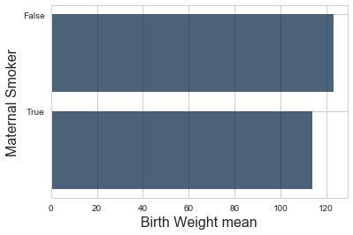

```python
baby.select("Maternal Smoker", "Birth Weight").group("Maternal Smoker", np.mean).barh("Maternal Smoker")
```

**Problem 5** (20 points)

Write a function

mean_birth_weight(query_age)

that returns the average birth weight of babies with Maternal Age = query_age if there are such babies in the data set, and "None" otherwise.

```python
def mean_birth_weight(query_age):
    subtab = baby.where("Maternal Age", are.equal_to(query_age))
    if subtab.num_rows == 0:
        return(None)
    else:
        return(np.mean(subtab.column("Birth Weight")))

print(mean_birth_weight(33))
print(mean_birth_weight(133))
```

```
123.285714286
None
```

**Problem 6** (10 points)

The average birth weight for babies of smokers is 114oz, while the average birth weight for babies of non-smokers is 123oz. Can you conclude that smoking causes low birth weight? Briefly justify your answer.

```python
# No. This is an observational study, not a randomized experiment.
# There could be confounders, for example nutrition during pregnancy,
# quality of prenatal care,.....
```

**Problem 7** (10 points)

In 1954 the Public Health Service conducted a study to test the effectiveness of Jonas Salk's polio vaccine. The incidence of polio among childred who were vaccinated was 28 per 100,000, while the incidence among unvaccinated children was 71 per 100,000. The Public Health Service concluded that the vaccine does indeed reduce the incidence of polio. What is the crucial aspect of the study that justifies this conclusion?

```python
# The Salk Vaccine Field Trial was a randomized experiment
```

**Problem 8** (5 points)

**Problem 9** (5 points)